# Project: Wrangle and Analyze Data

The following is a guided homework assignment for the Udacity Data Wrangling class where I downloaded, cleaned, and analyzed a dataset compiled from the Twitter account 'We Rate Dogs.' I've removed the homework instructions.

## Data Gathering

skip to Assessing Data  
skip to Cleaning Data  
skip to Insights

```python
#Header data:
import pandas as pd
import requests
import os
import numpy as np
```

```python
#Read in the data:
tweet_archive = pd.read_csv('twitter-archive-enhanced.csv')
tweet_json_full = pd.read_json('tweet-json.txt', lines=True)
tweet_json = tweet_json_full[['id', 'favorite_count', 'retweet_count']] #remove columns I'm not using
image_prediction = pd.read_csv('image_prediction.tsv', sep='\t')
```

## Assessing Data

### First, assess tweet_archive

#### Visual assessment:

```python
tweet_archive.head(10)
```

|  | tweet_id | in_reply_to_status_id | in_reply_to_user_id | timestamp | source | text | retweeted_status_id | retweeted_status_user_id | retweeted_status_timestamp | expanded_urls | rating_numerator | rating_denominator | name | doggo | floofer | pupper | puppo |
| --- | --- | --- | --- | --- | --- | --- | --- | --- | --- | --- | --- | --- | --- | --- | --- | --- | --- |
| 0 | 892420643555336193 | NaN | NaN | 2017-08-01 16:23:56 +0000 | <a href="http://twitter.com/download/iphone" r... | This is Phineas. He's a mystical boy. Only eve... | NaN | NaN | NaN | https://twitter.com/dog_rates/status/892420643... | 13 | 10 | Phineas | NaN | NaN | NaN | NaN |
| 1 | 892177421306343426 | NaN | NaN | 2017-08-01 00:17:27 +0000 | <a href="http://twitter.com/download/iphone" r... | This is Tilly. She's just checking pup on you.... | NaN | NaN | NaN | https://twitter.com/dog_rates/status/892177421... | 13 | 10 | Tilly | NaN | NaN | NaN | NaN |
| 2 | 891815181378084864 | NaN | NaN | 2017-07-31 00:18:03 +0000 | <a href="http://twitter.com/download/iphone" r... | This is Archie. He is a rare Norwegian Pouncin... | NaN | NaN | NaN | https://twitter.com/dog_rates/status/891815181... | 12 | 10 | Archie | NaN | NaN | NaN | NaN |
| 3 | 891689557279858688 | NaN | NaN | 2017-07-30 15:58:51 +0000 | <a href="http://twitter.com/download/iphone" r... | This is Darla. She commenced a snooze mid meal... | NaN | NaN | NaN | https://twitter.com/dog_rates/status/891689557... | 13 | 10 | Darla | NaN | NaN | NaN | NaN |
| 4 | 891327558926688256 | NaN | NaN | 2017-07-29 16:00:24 +0000 | <a href="http://twitter.com/download/iphone" r... | This is Franklin. He would like you to stop ca... | NaN | NaN | NaN | https://twitter.com/dog_rates/status/891327558... | 12 | 10 | Franklin | NaN | NaN | NaN | NaN |
| 5 | 891087950875897856 | NaN | NaN | 2017-07-29 00:08:17 +0000 | <a href="http://twitter.com/download/iphone" r... | Here we have a majestic great white breaching ... | NaN | NaN | NaN | https://twitter.com/dog_rates/status/891087950... | 13 | 10 | NaN | NaN | NaN | NaN | NaN |
| 6 | 890971913173991426 | NaN | NaN | 2017-07-28 16:27:12 +0000 | <a href="http://twitter.com/download/iphone" r... | Meet Jax. He enjoys ice cream so much he gets ... | NaN | NaN | NaN | https://gofundme.com/ydvmve-surgery-for-jax,ht... | 13 | 10 | Jax | NaN | NaN | NaN | NaN |
| 7 | 890729181411237888 | NaN | NaN | 2017-07-28 00:22:40 +0000 | <a href="http://twitter.com/download/iphone" r... | When you watch your owner call another dog a g... | NaN | NaN | NaN | https://twitter.com/dog_rates/status/890729181... | 13 | 10 | NaN | NaN | NaN | NaN | NaN |
| 8 | 890609185150312448 | NaN | NaN | 2017-07-27 16:25:51 +0000 | <a href="http://twitter.com/download/iphone" r... | This is Zoey. She doesn't want to be one of th... | NaN | NaN | NaN | https://twitter.com/dog_rates/status/890609185... | 13 | 10 | Zoey | NaN | NaN | NaN | NaN |
| 9 | 890240255349198849 | NaN | NaN | 2017-07-26 15:59:51 +0000 | <a href="http://twitter.com/download/iphone" r... | This is Cassie. She is a college pup. Studying... | NaN | NaN | NaN | https://twitter.com/dog_rates/status/890240255... | 14 | 10 | Cassie | doggo | NaN | NaN | NaN |

notes:

- source column includes HTML
- Mostly null values in the columns related to replies and retweats
- 'doggo', 'floofer', 'pupper', 'puppo' columns are all "none" on some rows (i.e. some rows missing stage data)

#### Programmatic Assessment

```python
tweet_archive.info()
```

```
<class 'pandas.core.frame.DataFrame'>
RangeIndex: 2356 entries, 0 to 2355
Data columns (total 17 columns):
 #   Column                      Non-Null Count  Dtype
---  ------                      --------------  -----
 0   tweet_id                    2356 non-null   int64
 1   in_reply_to_status_id       78 non-null     float64
 2   in_reply_to_user_id         78 non-null     float64
 3   timestamp                   2356 non-null   object
 4   source                      2356 non-null   object
 5   text                        2356 non-null   object
 6   retweeted_status_id         181 non-null    float64
 7   retweeted_status_user_id    181 non-null    float64
 8   retweeted_status_timestamp  181 non-null    object
 9   expanded_urls               2297 non-null   object
 10  rating_numerator            2356 non-null   int64
 11  rating_denominator          2356 non-null   int64
 12  name                        1611 non-null   object
 13  doggo                       97 non-null     object
 14  floofer                     10 non-null     object
 15  pupper                      257 non-null    object
 16  puppo                       30 non-null     object
dtypes: float64(4), int64(3), object(10)
memory usage: 313.0+ KB
```

notes:

- tweet_id is an int
- timestamp is a string
- doggo/floofer/pupper/puppo are strings
- missing values in expanded_url
- 78 rows are replies
- 181 rows are retweets

```python
tweet_archive.duplicated().sum()
```

```
0
```

No duplicated rows

```python
tweet_archive.tweet_id.nunique()
```

```
2356
```

No duplicated tweet ids.

```python
tweet_archive.rating_denominator.unique()
```

```
array([ 10,   0,  15,  70,   7,  11, 150, 170,  20,  50,  90,  80,  40,
       130, 110,  16, 120,   2], dtype=int64)
```

There are a few values in the denominator that aren't 10.

#### Look more closely at dog stage data

```python
#Figure out how many entries are missing dog stage data:
len(tweet_archive[((tweet_archive['doggo'] != 'doggo') &
              (tweet_archive['floofer'] != 'floofer') &
              (tweet_archive['pupper'] != 'pupper') &
              (tweet_archive['puppo'] != 'puppo)'))])
```

```
2005
```

2005 of these entries don't have dog stage data. Next, I'll see if the data is available in the text, which is where it was originally extracted from:

```python
#Figure out if stage data is available in the text:
with pd.option_context('display.max_colwidth', None): #this code stops pandas from truncating the text
    display(tweet_archive[((tweet_archive['doggo'] != 'doggo') &
              (tweet_archive['floofer'] != 'floofer') &
              (tweet_archive['pupper'] != 'pupper') &
              (tweet_archive['puppo'] != 'puppo)'))].text.sample())
```

```
751    Everybody drop what you're doing and look at this dog. 13/10 must be super h*ckin rare https://t.co/I1bJUzUEW5
Name: text, dtype: object
```

I ran the last cell a few times and didn't find any tweets that mention a dog stage. I conclude that some dogs don't have a stage.

#### Look more closely at dog name data

```python
tweet_archive.name.unique()
```

```
array(['Phineas', 'Tilly', 'Archie', 'Darla', 'Franklin', nan, 'Jax',
       'Zoey', 'Cassie', 'Koda', 'Bruno', 'Ted', 'Stuart', 'Oliver',
       'Jim', 'Zeke', 'Ralphus', 'Canela', 'Gerald', 'Jeffrey', 'such',
       'Maya', 'Mingus', 'Derek', 'Roscoe', 'Waffles', 'Jimbo', 'Maisey',
       'Lilly', 'Earl', 'Lola', 'Kevin', 'Yogi', 'Noah', 'Bella',
       'Grizzwald', 'Rusty', 'Gus', 'Stanley', 'Alfy', 'Koko', 'Rey',
       'Gary', 'a', 'Elliot', 'Louis', 'Jesse', 'Romeo', 'Bailey',
       'Duddles', 'Jack', 'Emmy', 'Steven', 'Beau', 'Snoopy', 'Shadow',
       'Terrance', 'Aja', 'Penny', 'Dante', 'Nelly', 'Ginger', 'Benedict',
       'Venti', 'Goose', 'Nugget', 'Cash', 'Coco', 'Jed', 'Sebastian',
       'Walter', 'Sierra', 'Monkey', 'Harry', 'Kody', 'Lassie', 'Rover',
       'Napolean', 'Dawn', 'Boomer', 'Cody', 'Rumble', 'Clifford',
       'quite', 'Dewey', 'Scout', 'Gizmo', 'Cooper', 'Harold', 'Shikha',
       'Jamesy', 'Lili', 'Sammy', 'Meatball', 'Paisley', 'Albus',
       'Neptune', 'Quinn', 'Belle', 'Zooey', 'Dave', 'Jersey', 'Hobbes',
       'Burt', 'Lorenzo', 'Carl', 'Jordy', 'Milky', 'Trooper', 'Winston',
       'Sophie', 'Wyatt', 'Rosie', 'Thor', 'Oscar', 'Luna', 'Callie',
       'Cermet', 'George', 'Marlee', 'Arya', 'Einstein', 'Alice',
       'Rumpole', 'Benny', 'Aspen', 'Jarod', 'Wiggles', 'General',
       'Sailor', 'Astrid', 'Iggy', 'Snoop', 'Kyle', 'Leo', 'Riley',
       'Gidget', 'Noosh', 'Odin', 'Jerry', 'Charlie', 'Georgie', 'Rontu',
       'Cannon', 'Furzey', 'Daisy', 'Tuck', 'Barney', 'Vixen', 'Jarvis',
       'Mimosa', 'Pickles', 'Bungalo', 'Brady', 'Margo', 'Sadie', 'Hank',
       'Tycho', 'Stephan', 'Indie', 'Winnie', 'Bentley', 'Ken', 'Max',
       'Maddie', 'Pipsy', 'Monty', 'Sojourner', 'Odie', 'Arlo', 'Sunny',
       'Vincent', 'Lucy', 'Clark', 'Mookie', 'Meera', 'Buddy', 'Ava',
       'Rory', 'Eli', 'Ash', 'Tucker', 'Tobi', 'Chester', 'Wilson',
       'Sunshine', 'Lipton', 'Gabby', 'Bronte', 'Poppy', 'Rhino',
       'Willow', 'not', 'Orion', 'Eevee', 'Smiley', 'Logan', 'Moreton',
       'Klein', 'Miguel', 'Emanuel', 'Kuyu', 'Dutch', 'Pete', 'Scooter',
       'Reggie', 'Kyro', 'Samson', 'Loki', 'Mia', 'Malcolm', 'Dexter',
       'Alfie', 'Fiona', 'one', 'Mutt', 'Bear', 'Doobert', 'Beebop',
       'Alexander', 'Sailer', 'Brutus', 'Kona', 'Boots', 'Ralphie',
       'Phil', 'Cupid', 'Pawnd', 'Pilot', 'Ike', 'Mo', 'Toby', 'Sweet',
       'Pablo', 'Nala', 'Balto', 'Crawford', 'Gabe', 'Mattie', 'Jimison',
       'Hercules', 'Duchess', 'Harlso', 'Sampson', 'Sundance', 'Luca',
       'Flash', 'Finn', 'Peaches', 'Howie', 'Jazzy', 'Anna', 'Bo',
       'Seamus', 'Wafer', 'Chelsea', 'Tom', 'Moose', 'Florence', 'Autumn',
       'Dido', 'Eugene', 'Herschel', 'Strudel', 'Tebow', 'Chloe', 'Betty',
       'Timber', 'Binky', 'Dudley', 'Comet', 'Larry', 'Levi', 'Akumi',
```

[output cut: 88 more lines]

```
       'Anthony', 'Holly', 'Jett', 'Amy', 'Sage', 'Andy', 'Mason',
       'Trigger', 'Antony', 'Creg', 'Traviss', 'Gin', 'Jeffrie', 'Danny',
       'Ester', 'Pluto', 'Bloo', 'Edd', 'Willy', 'Herb', 'Damon',
       'Peanut', 'Nigel', 'Butters', 'Sandra', 'Fabio', 'Randall', 'Liam',
       'Tommy', 'Ben', 'Raphael', 'Julio', 'Andru', 'Kloey', 'Shawwn',
       'Skye', 'Kollin', 'Ronduh', 'Billl', 'Saydee', 'Dug', 'Tessa',
       'Sully', 'Kirk', 'Ralf', 'Clarq', 'Jaspers', 'Samsom', 'Harrison',
       'Chaz', 'Jeremy', 'Jaycob', 'Lambeau', 'Ruffles', 'Amélie', 'Bobb',
       'Banditt', 'Kevon', 'Winifred', 'Hanz', 'Churlie', 'Zeek',
       'Timofy', 'Maks', 'Jomathan', 'Kallie', 'Marvin', 'Spark',
       'Gòrdón', 'Jo', 'DayZ', 'Jareld', 'Torque', 'Ron', 'Skittles',
       'Cleopatricia', 'Erik', 'Stu', 'Tedrick', 'Filup', 'Kial',
       'Naphaniel', 'Dook', 'Hall', 'Philippe', 'Biden', 'Fwed',
       'Genevieve', 'Joshwa', 'Bradlay', 'Clybe', 'Keet', 'Carll',
       'Jockson', 'Josep', 'Lugan', 'Christoper'], dtype=object)
```

```python
for name in tweet_archive.name[1:]:
    if type(name) == str:
        if name[0].isupper() == False:
            print(name)
```

```
such
a
quite
quite
quite
not
one
incredibly
a
mad
an
very
a
very
just
my
one
not
his
one
a
a
a
an
very
actually
a
just
getting
mad
very
this
unacceptable
all
a
old
a
infuriating
a
a
```

[output cut: 54 more lines]

```
a
quite
a
an
a
an
the
the
a
a
an
a
a
a
a
```

That's a lot of bad names, and some are duplicates. Let me look at some more closely to see if they have better names:

```python
with pd.option_context('display.max_colwidth', None): #this code stops pandas from truncating the text
    display(tweet_archive[(tweet_archive['name'] == 'a')].text.sample())
```

```
1737    Guys this really needs to stop. We've been over this way too many times. This is a giraffe. We only rate dogs.. 7/10 https://t.co/yavgkHYPOC
Name: text, dtype: object
```

I ran the cell above a few times and only found one name in any of the text.

### Next, assess tweet_json

```python
tweet_json.head(10)
```

|  | id | favorite_count | retweet_count |
| --- | --- | --- | --- |
| 0 | 892420643555336193 | 39467 | 8853 |
| 1 | 892177421306343426 | 33819 | 6514 |
| 2 | 891815181378084864 | 25461 | 4328 |
| 3 | 891689557279858688 | 42908 | 8964 |
| 4 | 891327558926688256 | 41048 | 9774 |
| 5 | 891087950875897856 | 20562 | 3261 |
| 6 | 890971913173991426 | 12041 | 2158 |
| 7 | 890729181411237888 | 56848 | 16716 |
| 8 | 890609185150312448 | 28226 | 4429 |
| 9 | 890240255349198849 | 32467 | 7711 |

No problems detected visually.

```python
tweet_json.info()
```

```
<class 'pandas.core.frame.DataFrame'>
RangeIndex: 2354 entries, 0 to 2353
Data columns (total 3 columns):
 #   Column          Non-Null Count  Dtype
---  ------          --------------  -----
 0   id              2354 non-null   int64
 1   favorite_count  2354 non-null   int64
 2   retweet_count   2354 non-null   int64
dtypes: int64(3)
memory usage: 55.3 KB
```

id is an int again. Missing some entries; 2,354 non-null values compared to 2,356 in tweet_archive

```python
tweet_json.duplicated().sum()
```

```
0
```

No duplicates

### Finally, assess image_prediction:

```python
image_prediction.head(10)
```

|  | tweet_id | jpg_url | img_num | p1 | p1_conf | p1_dog | p2 | p2_conf | p2_dog | p3 | p3_conf | p3_dog |
| --- | --- | --- | --- | --- | --- | --- | --- | --- | --- | --- | --- | --- |
| 0 | 666020888022790149 | https://pbs.twimg.com/media/CT4udn0WwAA0aMy.jpg | 1 | Welsh_springer_spaniel | 0.465074 | True | collie | 0.156665 | True | Shetland_sheepdog | 0.061428 | True |
| 1 | 666029285002620928 | https://pbs.twimg.com/media/CT42GRgUYAA5iDo.jpg | 1 | redbone | 0.506826 | True | miniature_pinscher | 0.074192 | True | Rhodesian_ridgeback | 0.072010 | True |
| 2 | 666033412701032449 | https://pbs.twimg.com/media/CT4521TWwAEvMyu.jpg | 1 | German_shepherd | 0.596461 | True | malinois | 0.138584 | True | bloodhound | 0.116197 | True |
| 3 | 666044226329800704 | https://pbs.twimg.com/media/CT5Dr8HUEAA-lEu.jpg | 1 | Rhodesian_ridgeback | 0.408143 | True | redbone | 0.360687 | True | miniature_pinscher | 0.222752 | True |
| 4 | 666049248165822465 | https://pbs.twimg.com/media/CT5IQmsXIAAKY4A.jpg | 1 | miniature_pinscher | 0.560311 | True | Rottweiler | 0.243682 | True | Doberman | 0.154629 | True |
| 5 | 666050758794694657 | https://pbs.twimg.com/media/CT5Jof1WUAEuVxN.jpg | 1 | Bernese_mountain_dog | 0.651137 | True | English_springer | 0.263788 | True | Greater_Swiss_Mountain_dog | 0.016199 | True |
| 6 | 666051853826850816 | https://pbs.twimg.com/media/CT5KoJ1WoAAJash.jpg | 1 | box_turtle | 0.933012 | False | mud_turtle | 0.045885 | False | terrapin | 0.017885 | False |
| 7 | 666055525042405380 | https://pbs.twimg.com/media/CT5N9tpXIAAifs1.jpg | 1 | chow | 0.692517 | True | Tibetan_mastiff | 0.058279 | True | fur_coat | 0.054449 | False |
| 8 | 666057090499244032 | https://pbs.twimg.com/media/CT5PY90WoAAQGLo.jpg | 1 | shopping_cart | 0.962465 | False | shopping_basket | 0.014594 | False | golden_retriever | 0.007959 | True |
| 9 | 666058600524156928 | https://pbs.twimg.com/media/CT5Qw94XAAA_2dP.jpg | 1 | miniature_poodle | 0.201493 | True | komondor | 0.192305 | True | soft-coated_wheaten_terrier | 0.082086 | True |

```python
image_prediction.info()
```

```
<class 'pandas.core.frame.DataFrame'>
RangeIndex: 2075 entries, 0 to 2074
Data columns (total 12 columns):
 #   Column    Non-Null Count  Dtype
---  ------    --------------  -----
 0   tweet_id  2075 non-null   int64
 1   jpg_url   2075 non-null   object
 2   img_num   2075 non-null   int64
 3   p1        2075 non-null   object
 4   p1_conf   2075 non-null   float64
 5   p1_dog    2075 non-null   bool
 6   p2        2075 non-null   object
 7   p2_conf   2075 non-null   float64
 8   p2_dog    2075 non-null   bool
 9   p3        2075 non-null   object
 10  p3_conf   2075 non-null   float64
 11  p3_dog    2075 non-null   bool
dtypes: bool(3), float64(3), int64(2), object(4)
memory usage: 152.1+ KB
```

'id' is an int again.  
There are missing values. This dataset only has 2,075 values, whereas there were 2,356 values in tweet_archive

```python
image_prediction.duplicated().sum()
```

```
0
```

No duplicates.

```python
image_prediction.tweet_id.duplicated().sum()
```

```
0
```

No duplicate tweet_ids.

```python
image_prediction.img_num.unique()
```

```
array([1, 4, 2, 3], dtype=int64)
```

I'm not sure what the img_num column is, but it has four possible values.

```python
#Use image_prediction to find entries that are probably not dogs
len(image_prediction[(image_prediction['p1_dog'] == False) &
                    (image_prediction['p2_dog'] == False) &
                    (image_prediction['p3_dog'] == False)])
```

```
324
```

### Quality issues

1. There are over 200 replies and retweets included in the dataset
2. The 'name' column has invalid values (e.g. 'None').
3. Some of the images are probably not dogs, per image_prediction
4. tweet_id is an int, but should be a string. Timestamp is a string, but should be a datetime.
5. Doggo/floofer/pupper/puppo are strings, but should be categories
6. Some expanded_urls are missing
7. There are values in the denominator that aren't 10.
8. There are only 2,075 images, but 2,356 tweets (some tweets are missing images)

### Tidiness issues

1. The "favorite_count" and "retweet_count" columns should be moved from "tweet_json" to the main tweet dataframe
2. The "doggo, floofer, pupper, and puppo" columns all contain the same data: dog stage

## Cleaning Data

```python
# Make copies of original pieces of data
tweets = tweet_archive.copy() #tweets will be the master dataframe
```

### Tidiness Issue #1: The "favorite_count" and "retweet_count" columns should be moved from "tweet_json" to the main tweet dataframe

#### Define: Merge "favorite_count" and "retweet_count" columns into the tweets dataframe

#### Code

```python
tweet_json.rename(columns={"id": "tweet_id"}, inplace=True) #harmonize id column names so we can merge on them
```

```python
#merge tweet_json into tweets:
tweets = pd.merge(tweets, tweet_json, on='tweet_id', how='left')
```

#### Test

```python
tweets.head(1)
```

|  | tweet_id | in_reply_to_status_id | in_reply_to_user_id | timestamp | source | text | retweeted_status_id | retweeted_status_user_id | retweeted_status_timestamp | expanded_urls | rating_numerator | rating_denominator | name | doggo | floofer | pupper | puppo | favorite_count | retweet_count |
| --- | --- | --- | --- | --- | --- | --- | --- | --- | --- | --- | --- | --- | --- | --- | --- | --- | --- | --- | --- |
| 0 | 892420643555336193 | NaN | NaN | 2017-08-01 16:23:56 +0000 | <a href="http://twitter.com/download/iphone" r... | This is Phineas. He's a mystical boy. Only eve... | NaN | NaN | NaN | https://twitter.com/dog_rates/status/892420643... | 13 | 10 | Phineas | NaN | NaN | NaN | NaN | 39467.0 | 8853.0 |

```python
#Pandas turned favorite_count and retweet_count into floats. Changing them back:
tweets.favorite_count = tweets.favorite_count.fillna(0).astype(int)
tweets.retweet_count = tweets.retweet_count.fillna(0).astype(int)
#note: using fillna(0) because NaN can't be directly converted to int.
```

```python
#re-test:
tweets.head(1)
```

|  | tweet_id | in_reply_to_status_id | in_reply_to_user_id | timestamp | source | text | retweeted_status_id | retweeted_status_user_id | retweeted_status_timestamp | expanded_urls | rating_numerator | rating_denominator | name | doggo | floofer | pupper | puppo | favorite_count | retweet_count |
| --- | --- | --- | --- | --- | --- | --- | --- | --- | --- | --- | --- | --- | --- | --- | --- | --- | --- | --- | --- |
| 0 | 892420643555336193 | NaN | NaN | 2017-08-01 16:23:56 +0000 | <a href="http://twitter.com/download/iphone" r... | This is Phineas. He's a mystical boy. Only eve... | NaN | NaN | NaN | https://twitter.com/dog_rates/status/892420643... | 13 | 10 | Phineas | NaN | NaN | NaN | NaN | 39467 | 8853 |

### Quality Issue #1: A little over 200 replies and retweets included in the dataset

#### Define: delete tweets that are replies and retweets, then delete the reply/retweet columns

#### Code

```python
#First, count the number of tweets that are replies or retweets
#This function counts the number of rows where there is a value in a reply or retweet column
len(tweets[((tweets['in_reply_to_status_id'].notnull()) |
        (tweets['in_reply_to_user_id'].notnull()) |
        (tweets['retweeted_status_id'].notnull()) |
        (tweets['retweeted_status_user_id'].notnull()) |
        (tweets['retweeted_status_timestamp'].notnull()))])
```

```
259
```

```python
#Remove rows with replies and retweets:
tweets = tweets[((tweets['in_reply_to_status_id'].isnull()) &
                 (tweets['in_reply_to_user_id'].isnull()) &
                 (tweets['retweeted_status_id'].isnull()) &
                 (tweets['retweeted_status_user_id'].isnull()) &
                 (tweets['retweeted_status_timestamp'].isnull()))]
```

#### Test

```python
#use tweets.info() to see if there are still non-null values in reply and retweet columns:
tweets.info()
```

```
<class 'pandas.core.frame.DataFrame'>
Index: 2097 entries, 0 to 2355
Data columns (total 19 columns):
 #   Column                      Non-Null Count  Dtype
---  ------                      --------------  -----
 0   tweet_id                    2097 non-null   int64
 1   in_reply_to_status_id       0 non-null      float64
 2   in_reply_to_user_id         0 non-null      float64
 3   timestamp                   2097 non-null   object
 4   source                      2097 non-null   object
 5   text                        2097 non-null   object
 6   retweeted_status_id         0 non-null      float64
 7   retweeted_status_user_id    0 non-null      float64
 8   retweeted_status_timestamp  0 non-null      object
 9   expanded_urls               2094 non-null   object
 10  rating_numerator            2097 non-null   int64
 11  rating_denominator          2097 non-null   int64
 12  name                        1494 non-null   object
 13  doggo                       83 non-null     object
 14  floofer                     10 non-null     object
 15  pupper                      230 non-null    object
 16  puppo                       24 non-null     object
 17  favorite_count              2097 non-null   int32
 18  retweet_count               2097 non-null   int32
dtypes: float64(4), int32(2), int64(3), object(10)
memory usage: 311.3+ KB
```

```python
#Now I can remove reply and retweet columns:
tweets.drop(['in_reply_to_status_id', 'in_reply_to_user_id', 'retweeted_status_id', 'retweeted_status_user_id',
            'retweeted_status_timestamp'], axis=1, inplace=True)
```

#### Test 2

```python
#Verify that those columns have been dropped:
tweets.head(1)
```

|  | tweet_id | timestamp | source | text | expanded_urls | rating_numerator | rating_denominator | name | doggo | floofer | pupper | puppo | favorite_count | retweet_count |
| --- | --- | --- | --- | --- | --- | --- | --- | --- | --- | --- | --- | --- | --- | --- |
| 0 | 892420643555336193 | 2017-08-01 16:23:56 +0000 | <a href="http://twitter.com/download/iphone" r... | This is Phineas. He's a mystical boy. Only eve... | https://twitter.com/dog_rates/status/892420643... | 13 | 10 | Phineas | NaN | NaN | NaN | NaN | 39467 | 8853 |

### Quality Issue #2: invalid/missing data from name column

#### Define: Create a custom transformation function to change invalid names to 'NaN', since the data cannot be found in other sources. Also create a new column, "None", for stages to store a NaN value if the entry has no stage data.

```python
#First, count how many names are bad, and how many are already null. This is used for testing later:
bad_name_counter = 0
for name in tweets.name[1:]:
    if type(name) == str:
        if name[0].isupper() == False:
            bad_name_counter += 1
print('bad: ', bad_name_counter)
print('null: ', tweets.name.isnull().sum())
```

```
bad:  104
null:  603
```

```python
#Create a custom transformation function to change names to null:
def null_names(name):
    if type(name) == str:
        if (name[0].isupper() == False):
            return None
        else: return name
```

```python
#Run names through the transformation function
tweets['name'] = tweets['name'].transform(null_names)
```

#### Test

```python
#Verify that some of the names are now null:
tweets.name.isnull().sum()
```

```
707
```

All 104 names with lower-case first letters have been changed to null.

### Quality Issue #3: Some of the images are probably not dogs, per image_prediction

#### Define: Make a list of the tweet_ids that are not associated with a dog prediction. Remove those IDs/tweets from the main tweets dataframe.

#### Code:

```python
#Isolate the entries in image_prediction that are probably not dogs:
not_dogs = image_prediction[(image_prediction['p1_dog'] == False) &
                    (image_prediction['p2_dog'] == False) &
                    (image_prediction['p3_dog'] == False)]
len(not_dogs)#count the number of entries that aren't dogs to aid in testing, below
```

```
324
```

```python
#make a new dataframe out of the tweets whose ID doesn't match one in not_dogs using .isin and ~ functions.
#track the number of tweets that were removed for testing.
print('tweets in tweets: ', len(tweets))
removed_non_dogs = tweets[~(tweets.tweet_id.isin(not_dogs.tweet_id))]
print('tweets in removed_non_dogs: ', len(removed_non_dogs))
```

```
tweets in tweets:  2097
tweets in removed_non_dogs:  1792
```

#### Test:

```python
2097-1792 #see if 324 entries were removed:
```

```
305
```

```python
#fewer entries were removed than were in not_dogs. see if there are duplicates in not_dogs:
not_dogs.duplicated().sum()
```

```
0
```

There are no duplicates in not_dogs. It's probably the case that there were entries in image_prediction that weren't in tweets, and for that reason not every row in not_dogs caused a row to be removed from tweets. The final step is to copy removed_non_dogs back into the tweets master dataframe:

```python
tweets = removed_non_dogs.copy()
```

### Tidiness Issue #2: 'doggo', 'floofer,' etc. contain the same data point, and are missing data

#### Define: melt these four columns into one that's titled 'stage', then drop them.

#### Code

```python
tweets.pupper.unique() #test 'pupper' column to see what values are in it
```

```
array([nan, 'pupper'], dtype=object)
```

```python
#First, create a column to hold a value when no dog stage is mentioned.
#This will help when I need to delete rows after melting.
tweets_test = tweets.copy() #work with a copy
tweets_test['no_stage'] = "None"
```

```python
#Next, change the value in no_stage to "no_stage" when there is really no stage data:
tweets_test.loc[((tweets_test['doggo'].isnull()) &
                (tweets_test['floofer'].isnull()) &
                (tweets_test['pupper'].isnull()) &
                (tweets_test['puppo'].isnull())), 'no_stage'] = "no_stage"
```

```python
#test that changing values to "no_stage" worked:
tweets_test.head(5)
```

|  | tweet_id | timestamp | source | text | expanded_urls | rating_numerator | rating_denominator | name | doggo | floofer | pupper | puppo | favorite_count | retweet_count | no_stage |
| --- | --- | --- | --- | --- | --- | --- | --- | --- | --- | --- | --- | --- | --- | --- | --- |
| 1 | 892177421306343426 | 2017-08-01 00:17:27 +0000 | <a href="http://twitter.com/download/iphone" r... | This is Tilly. She's just checking pup on you.... | https://twitter.com/dog_rates/status/892177421... | 13 | 10 | Tilly | NaN | NaN | NaN | NaN | 33819 | 6514 | no_stage |
| 2 | 891815181378084864 | 2017-07-31 00:18:03 +0000 | <a href="http://twitter.com/download/iphone" r... | This is Archie. He is a rare Norwegian Pouncin... | https://twitter.com/dog_rates/status/891815181... | 12 | 10 | Archie | NaN | NaN | NaN | NaN | 25461 | 4328 | no_stage |
| 3 | 891689557279858688 | 2017-07-30 15:58:51 +0000 | <a href="http://twitter.com/download/iphone" r... | This is Darla. She commenced a snooze mid meal... | https://twitter.com/dog_rates/status/891689557... | 13 | 10 | Darla | NaN | NaN | NaN | NaN | 42908 | 8964 | no_stage |
| 4 | 891327558926688256 | 2017-07-29 16:00:24 +0000 | <a href="http://twitter.com/download/iphone" r... | This is Franklin. He would like you to stop ca... | https://twitter.com/dog_rates/status/891327558... | 12 | 10 | Franklin | NaN | NaN | NaN | NaN | 41048 | 9774 | no_stage |
| 5 | 891087950875897856 | 2017-07-29 00:08:17 +0000 | <a href="http://twitter.com/download/iphone" r... | Here we have a majestic great white breaching ... | https://twitter.com/dog_rates/status/891087950... | 13 | 10 | None | NaN | NaN | NaN | NaN | 20562 | 3261 | no_stage |

```python
#Merge the stage columns into one column:

#First, fill null values with blank spaces so that I can combine them using the + operator:
#(a NaN in one column + any other value = NaN)
tweets_test[['doggo', 'floofer', 'pupper', 'puppo']] = tweets_test[['doggo', 'floofer', 'pupper', 'puppo']].fillna('')
#Next, merge using the + operator:
tweets_test['stage'] = tweets_test.floofer + tweets_test.pupper + tweets_test.puppo + tweets_test.doggo
#Next, drop the old stage data and copy the data to tweets_merged
tweets_merged = tweets_test.drop(['doggo', 'floofer', 'pupper', 'puppo', 'no_stage'], axis=1)
```

```python
#Check that the dataframe length hasn't changed:
tweets_merged.shape
```

```
(1792, 11)
```

```python
#Check that the 'stage' column has merged correctly by taking a sample:
tweets_merged.sample(5)
```

|  | tweet_id | timestamp | source | text | expanded_urls | rating_numerator | rating_denominator | name | favorite_count | retweet_count | stage |
| --- | --- | --- | --- | --- | --- | --- | --- | --- | --- | --- | --- |
| 2275 | 667453023279554560 | 2015-11-19 21:22:56 +0000 | <a href="http://twitter.com" rel="nofollow">Tw... | Meet Cupcake. I would do unspeakable things fo... | https://twitter.com/dog_rates/status/667453023... | 11 | 10 | Cupcake | 327 | 96 |  |
| 2095 | 670764103623966721 | 2015-11-29 00:39:59 +0000 | <a href="http://twitter.com/download/iphone" r... | Meet Vincent. He's a wild Adderall Cayenne. Sh... | https://twitter.com/dog_rates/status/670764103... | 10 | 10 | Vincent | 1154 | 466 |  |
| 244 | 846042936437604353 | 2017-03-26 16:55:29 +0000 | <a href="http://twitter.com/download/iphone" r... | Meet Jarvis. The snow pupsets him. Officially ... | https://twitter.com/dog_rates/status/846042936... | 12 | 10 | Jarvis | 17256 | 3224 |  |
| 1863 | 675372240448454658 | 2015-12-11 17:51:04 +0000 | <a href="http://twitter.com/download/iphone" r... | The tail alone is 13/10. Great dog, better own... | https://twitter.com/dog_rates/status/675372240... | 13 | 10 | None | 1838 | 563 |  |
| 1161 | 723912936180330496 | 2016-04-23 16:34:28 +0000 | <a href="http://twitter.com/download/iphone" r... | This is Sugar. She's a Bolivian Superfloof. Sp... | https://twitter.com/dog_rates/status/723912936... | 12 | 10 | Sugar | 4236 | 1374 |  |

```python
tweets_test[tweets_test['puppo'] == 'puppo'].index
```

```
Index([  12,   14,   71,   94,  129,  168,  191,  395,  398,  413,  439,  554,
        567,  643,  663,  689,  713,  922,  947,  961, 1035, 1048, 1083],
      dtype='int64')
```

```python
tweets_test.loc[191].text
```

```
"Here's a puppo participating in the #ScienceMarch. Cleverly disguising her own doggo agenda. 13/10 would keep the planet habitable for https://t.co/cMhq16isel"
```

```python
#I happened to check 'puppo' entries and found that one tweet has both a puppo stage and a doggo stage. I'm removing that entry from the dataframe:
tweets_merged.drop(index = 191, axis=0, inplace=True)
```

```python
#I should check to see if any other stages have that issue:
np.setdiff1d(tweets_test[tweets_test['pupper'] == 'pupper'].index, tweets_merged[tweets_merged['stage'] == 'pupper'].index)
```

```
array([ 460,  531,  575,  733,  889,  956, 1063, 1113], dtype=int64)
```

```python
tweets_test.loc[531].text
```

```
'Here we have Burke (pupper) and Dexter (doggo). Pupper wants to be exactly like doggo. Both 12/10 would pet at same time https://t.co/ANBpEYHaho'
```

```python
#Same deal; multiple values in the 'stage' dimension. Removing those rows:
tweets_merged.drop(index=[460, 531, 575, 733, 889, 956, 1063, 1113], axis=0, inplace=True)
```

```python
#Now checking 'floofer':
to_delete = np.setdiff1d(tweets_test[tweets_test['floofer'] == 'floofer'].index, tweets_merged[tweets_merged['stage'] == 'floofer'].index)
to_delete
```

```
array([200], dtype=int64)
```

```python
tweets_merged.drop(index=200, axis=0, inplace=True)
```

```python
#now checking Doggo:
to_delete = np.setdiff1d(tweets_test[tweets_test['doggo'] == 'doggo'].index, tweets_merged[tweets_merged['stage'] == 'doggo'].index)
to_delete
```

```
array([ 191,  200,  460,  531,  575,  733,  889,  956, 1063, 1113],
      dtype=int64)
```

```python
tweets_merged.drop(index=to_delete, axis=0, inplace=True, errors='ignore')
```

```python
#Change blank 'stage' values to np.nan using a custom function:

#Create a custom transformation function to change stages to null:
def null_stage(stage):
    if (stage == ""):
        return np.nan
    else: return stage

#Run stage through the transformation function
tweets_merged['stage'] = tweets_merged['stage'].transform(null_stage)
```

```python
tweets_merged.sample(2)
```

|  | tweet_id | timestamp | source | text | expanded_urls | rating_numerator | rating_denominator | name | favorite_count | retweet_count | stage |
| --- | --- | --- | --- | --- | --- | --- | --- | --- | --- | --- | --- |
| 494 | 813187593374461952 | 2016-12-26 01:00:05 +0000 | <a href="http://twitter.com/download/iphone" r... | We only rate dogs. Please don't send in other ... | https://twitter.com/dog_rates/status/813187593... | 13 | 10 | None | 22085 | 5096 | NaN |
| 955 | 751598357617971201 | 2016-07-09 02:06:27 +0000 | <a href="http://twitter.com/download/iphone" r... | This is Toby. A cat got his tongue. 13/10 ador... | https://twitter.com/dog_rates/status/751598357... | 13 | 10 | Toby | 8699 | 3440 | NaN |

```python
#copy tweets_merged back into tweets:
tweets = tweets_merged.copy()
```

### Quality Issue 4: tweet_id is an int, but should be a string. Timestamp is a string, but should be a datetime.

#### Define: use astype to change tweet_id to a string and pd.to_datetime to change timestamp to a datetime.

#### Code:

```python
tweets.tweet_id = tweets.tweet_id.astype(str)
tweets.timestamp = pd.to_datetime(tweets.timestamp)
```

#### Test:

```python
#Make sure everything looks good
tweets.head(1)
```

|  | tweet_id | timestamp | source | text | expanded_urls | rating_numerator | rating_denominator | name | favorite_count | retweet_count | stage |
| --- | --- | --- | --- | --- | --- | --- | --- | --- | --- | --- | --- |
| 1 | 892177421306343426 | 2017-08-01 00:17:27+00:00 | <a href="http://twitter.com/download/iphone" r... | This is Tilly. She's just checking pup on you.... | https://twitter.com/dog_rates/status/892177421... | 13 | 10 | Tilly | 33819 | 6514 | NaN |

```python
#make sure the types really changed:
print('tweet_id type:', tweets.tweet_id.dtype)
print('timestamp type: ', tweets.timestamp.dtype)
```

```
tweet_id type: object
timestamp type:  datetime64[ns, UTC]
```

### Quality Issue 5: Doggo/floofer/pupper/puppo are strings, but should be categories

#### Define:

use astype() to change the stage column to a category type

#### Code:

```python
tweets.stage = tweets.stage.astype('category')
```

#### Test:

```python
tweets.stage.dtype
```

```
CategoricalDtype(categories=['doggo', 'floofer', 'pupper', 'puppo'], ordered=False, categories_dtype=object)
```

### Quality Issue 6: Some expanded_urls are missing

### Define:

re-fill the expanded_url column by appending the tweet_id onto the generalized url "https://twitter.com/dog_rates/status/"

#### Code:

```python
pd.set_option('display.max_colwidth', None) #this code stops pandas from truncating the text
```

```python
tweets[['tweet_id', 'expanded_urls']]
```

|  | tweet_id | expanded_urls |
| --- | --- | --- |
| 1 | 892177421306343426 | https://twitter.com/dog_rates/status/892177421306343426/photo/1 |
| 2 | 891815181378084864 | https://twitter.com/dog_rates/status/891815181378084864/photo/1 |
| 3 | 891689557279858688 | https://twitter.com/dog_rates/status/891689557279858688/photo/1 |
| 4 | 891327558926688256 | https://twitter.com/dog_rates/status/891327558926688256/photo/1,https://twitter.com/dog_rates/status/891327558926688256/photo/1 |
| 5 | 891087950875897856 | https://twitter.com/dog_rates/status/891087950875897856/photo/1 |
| ... | ... | ... |
| 2351 | 666049248165822465 | https://twitter.com/dog_rates/status/666049248165822465/photo/1 |
| 2352 | 666044226329800704 | https://twitter.com/dog_rates/status/666044226329800704/photo/1 |
| 2353 | 666033412701032449 | https://twitter.com/dog_rates/status/666033412701032449/photo/1 |
| 2354 | 666029285002620928 | https://twitter.com/dog_rates/status/666029285002620928/photo/1 |
| 2355 | 666020888022790149 | https://twitter.com/dog_rates/status/666020888022790149/photo/1 |

1782 rows × 2 columns

```python
#All URLs follow this pattern: "https://twitter.com/dog_rates/status/" + tweet_id + "/photo/1"
#Some of these fields repeat the same URL several times
```

```python
#replace expanded_urls with new url created by linking strings:
tweets['expanded_urls'] = ("https://twitter.com/dog_rates/status/" + tweets.tweet_id + "/photo/1")
```

#### Test:

```python
#Look at new urls to make sure they match their row's id, and also have the correct format:
tweets[['tweet_id', 'expanded_urls']]
```

|  | tweet_id | expanded_urls |
| --- | --- | --- |
| 1 | 892177421306343426 | https://twitter.com/dog_rates/status/892177421306343426/photo/1 |
| 2 | 891815181378084864 | https://twitter.com/dog_rates/status/891815181378084864/photo/1 |
| 3 | 891689557279858688 | https://twitter.com/dog_rates/status/891689557279858688/photo/1 |
| 4 | 891327558926688256 | https://twitter.com/dog_rates/status/891327558926688256/photo/1 |
| 5 | 891087950875897856 | https://twitter.com/dog_rates/status/891087950875897856/photo/1 |
| ... | ... | ... |
| 2351 | 666049248165822465 | https://twitter.com/dog_rates/status/666049248165822465/photo/1 |
| 2352 | 666044226329800704 | https://twitter.com/dog_rates/status/666044226329800704/photo/1 |
| 2353 | 666033412701032449 | https://twitter.com/dog_rates/status/666033412701032449/photo/1 |
| 2354 | 666029285002620928 | https://twitter.com/dog_rates/status/666029285002620928/photo/1 |
| 2355 | 666020888022790149 | https://twitter.com/dog_rates/status/666020888022790149/photo/1 |

1782 rows × 2 columns

```python
#make sure there are no longer any null values in expanded_urls:
tweets.info()
```

```
<class 'pandas.core.frame.DataFrame'>
Index: 1782 entries, 1 to 2355
Data columns (total 11 columns):
 #   Column              Non-Null Count  Dtype
---  ------              --------------  -----
 0   tweet_id            1782 non-null   object
 1   timestamp           1782 non-null   datetime64[ns, UTC]
 2   source              1782 non-null   object
 3   text                1782 non-null   object
 4   expanded_urls       1782 non-null   object
 5   rating_numerator    1782 non-null   int64
 6   rating_denominator  1782 non-null   int64
 7   name                1224 non-null   object
 8   favorite_count      1782 non-null   int32
 9   retweet_count       1782 non-null   int32
 10  stage               280 non-null    category
dtypes: category(1), datetime64[ns, UTC](1), int32(2), int64(2), object(5)
memory usage: 141.2+ KB
```

### Quality Issue 7: Values in the denominator that aren't 10.

#### Define:

- Determine whether values in the denominator aren't 10 on purpose by reviewing the associated text.
- If all denominators should be 10, then remove the denominator column for being unnecessary.

#### Code:

```python
#isolate some of the rows where the value in the denominator isn't 10:
with pd.option_context('display.max_colwidth', None): #this code stops pandas from truncating the text
    display(tweets[tweets['rating_denominator'] != 10].sample(5))
```

|  | tweet_id | timestamp | source | text | expanded_urls | rating_numerator | rating_denominator | name | favorite_count | retweet_count | stage |
| --- | --- | --- | --- | --- | --- | --- | --- | --- | --- | --- | --- |
| 902 | 758467244762497024 | 2016-07-28 01:00:57+00:00 | <a href="http://twitter.com/download/iphone" rel="nofollow">Twitter for iPhone</a> | Why does this never happen at my front door... 165/150 https://t.co/HmwrdfEfUE | https://twitter.com/dog_rates/status/758467244762497024/photo/1 | 165 | 150 | None | 5316 | 2539 | NaN |
| 2335 | 666287406224695296 | 2015-11-16 16:11:11+00:00 | <a href="http://twitter.com/download/iphone" rel="nofollow">Twitter for iPhone</a> | This is an Albanian 3 1/2 legged Episcopalian. Loves well-polished hardwood flooring. Penis on the collar. 9/10 https://t.co/d9NcXFKwLv | https://twitter.com/dog_rates/status/666287406224695296/photo/1 | 1 | 2 | None | 152 | 71 | NaN |
| 1843 | 675853064436391936 | 2015-12-13 01:41:41+00:00 | <a href="http://twitter.com/download/iphone" rel="nofollow">Twitter for iPhone</a> | Here we have an entire platoon of puppers. Total score: 88/80 would pet all at once https://t.co/y93p6FLvVw | https://twitter.com/dog_rates/status/675853064436391936/photo/1 | 88 | 80 | None | 2927 | 1460 | NaN |
| 1274 | 709198395643068416 | 2016-03-14 02:04:08+00:00 | <a href="http://twitter.com/download/iphone" rel="nofollow">Twitter for iPhone</a> | From left to right:\nCletus, Jerome, Alejandro, Burp, &amp; Titson\nNone know where camera is. 45/50 would hug all at once https://t.co/sedre1ivTK | https://twitter.com/dog_rates/status/709198395643068416/photo/1 | 45 | 50 | None | 2634 | 721 | NaN |
| 1433 | 697463031882764288 | 2016-02-10 16:51:59+00:00 | <a href="http://twitter.com/download/iphone" rel="nofollow">Twitter for iPhone</a> | Happy Wednesday here's a bucket of pups. 44/40 would pet all at once https://t.co/HppvrYuamZ | https://twitter.com/dog_rates/status/697463031882764288/photo/1 | 44 | 40 | None | 3748 | 1552 | NaN |

It looks like there are two things causing this issue: one is that the algorithm incorrectly pulled a ratio out of the text that wasn't meant to be a rating (e.g. 24/7 or 50/50), and another is that these tweets deal with groups of dogs. Either way, these tweets probably don't really contribute to an analysis of the dogs, so I'm going to remove all of them and then remove the "rating_denominator" column.

```python
tweets = tweets[tweets['rating_denominator'] == 10]
```

```python
tweets.drop(columns='rating_denominator', axis=1, inplace=True)
```

#### Test:

```python
#Make sure the denominator column is gone:
tweets.info()
```

```
<class 'pandas.core.frame.DataFrame'>
Index: 1766 entries, 1 to 2355
Data columns (total 10 columns):
 #   Column            Non-Null Count  Dtype
---  ------            --------------  -----
 0   tweet_id          1766 non-null   object
 1   timestamp         1766 non-null   datetime64[ns, UTC]
 2   source            1766 non-null   object
 3   text              1766 non-null   object
 4   expanded_urls     1766 non-null   object
 5   rating_numerator  1766 non-null   int64
 6   name              1221 non-null   object
 7   favorite_count    1766 non-null   int32
 8   retweet_count     1766 non-null   int32
 9   stage             280 non-null    category
dtypes: category(1), datetime64[ns, UTC](1), int32(2), int64(1), object(5)
memory usage: 126.1+ KB
```

### Quality Issue 8: Some tweets are missing images

#### Define:

- Verify that there are still tweets in the tweets database that are missing images (the database has shrunk a lot, so that might not be an issue anymore).
- Remove tweets that are missing images

#### Code:

```python
#First, image_prediction.tweet_id has to also be a string so it can be compared to tweets.tweet_id:
image_prediction.tweet_id = image_prediction.tweet_id.astype(str)
```

```python
#Next, check to see if any tweets that have survived the cleaning process are missing images:
len(tweets[~(tweets.tweet_id.isin(image_prediction.tweet_id))])
```

```
125
```

125 tweets in 'tweets' are missing images. Next, remove those tweets:

```python
tweets = tweets[(tweets.tweet_id.isin(image_prediction.tweet_id))]
```

#### Test:

```python
# See if any image-less tweets are still in 'tweets':
len(tweets[~(tweets.tweet_id.isin(image_prediction.tweet_id))])
```

```
0
```

## Storing Data

Save gathered, assessed, and cleaned master dataset to a CSV file named "twitter_archive_master.csv".

```python
#First, merge the most important columns from image_prediction into tweets.
#the tweet_id column in image_prediction will have to be a string datatype:
image_prediction.tweet_id = image_prediction.tweet_id.astype(str)
#Then merge them:
tweets = pd.merge(tweets, image_prediction[['tweet_id','p1', 'p1_conf', 'p2', 'p2_conf', 'p3', 'p3_conf']],
on='tweet_id', how='left') #not merging image_urls
```

```python
#write 'tweets' to twitter_archive_master.csv
tweets.to_csv('twitter_archive_master.csv')
```

## Analyzing and Visualizing Data

In this section, analyze and visualize your wrangled data. You must produce at least **three (3) insights and one (1) visualization.**

```python
#Insight search 1: does a dog's score correlate to higher tweets recounts and favorites?
#Method 1: Create a regression model to look at a rating's effect on favorite count:
import statsmodels.api as sm
tweets['intercept'] = 1
lm = sm.OLS(tweets['favorite_count'], tweets[['intercept', 'rating_numerator']])
results = lm.fit()
results.summary()
```

OLS Regression Results

| Dep. Variable: | favorite_count | R-squared: | 0.103 |
| --- | --- | --- | --- |
| Model: | OLS | Adj. R-squared: | 0.103 |
| Method: | Least Squares | F-statistic: | 188.9 |
| Date: | Wed, 11 Dec 2024 | Prob (F-statistic): | 9.10e-41 |
| Time: | 19:33:37 | Log-Likelihood: | -17738. |
| No. Observations: | 1641 | AIC: | 3.548e+04 |
| Df Residuals: | 1639 | BIC: | 3.549e+04 |
| Df Model: | 1 |  |  |
| Covariance Type: | nonrobust |  |  |

|  | coef | std err | t | P>\|t\| | [0.025 | 0.975] |
| --- | --- | --- | --- | --- | --- | --- |
| intercept | -8833.1149 | 1349.691 | -6.545 | 0.000 | -1.15e+04 | -6185.815 |
| rating_numerator | 1664.3900 | 121.093 | 13.745 | 0.000 | 1426.877 | 1901.903 |

| Omnibus: | 1326.347 | Durbin-Watson: | 1.349 |
| --- | --- | --- | --- |
| Prob(Omnibus): | 0.000 | Jarque-Bera (JB): | 50609.350 |
| Skew: | 3.487 | Prob(JB): | 0.00 |
| Kurtosis: | 29.297 | Cond. No. | 51.3 |

Notes:  
[1] Standard Errors assume that the covariance matrix of the errors is correctly specified.

Yes, there is definitely correlation: every 1 point increase in the numerator correlates to 1664 more favorite counts. With a p-value of 0, this is statistically significant.

```python
#Method 2: from https://medium.com/analytics-vidhya/linear-regression-using-pandas-numpy-for-beginners-in-data-science-fe57157ed93d
from sklearn.model_selection import train_test_split
from sklearn.linear_model import LinearRegression
X = tweets[['rating_numerator']]
Y = tweets['favorite_count']
X_train, X_test, Y_train, Y_test = train_test_split(X,Y, test_size=0.3,random_state=101)
lm = LinearRegression()
results = lm.fit(X_train,Y_train)
print(lm.coef_)
```

```
[1525.76696678]
```

This method of creating a linear model came up with a similar coefficient.

```python
#Next, do the same with retweet counts:
lm = sm.OLS(tweets['retweet_count'], tweets[['intercept', 'rating_numerator']])
results = lm.fit()
results.summary()
```

OLS Regression Results

| Dep. Variable: | retweet_count | R-squared: | 0.060 |
| --- | --- | --- | --- |
| Model: | OLS | Adj. R-squared: | 0.059 |
| Method: | Least Squares | F-statistic: | 104.6 |
| Date: | Wed, 11 Dec 2024 | Prob (F-statistic): | 7.62e-24 |
| Time: | 19:33:38 | Log-Likelihood: | -16195. |
| No. Observations: | 1641 | AIC: | 3.239e+04 |
| Df Residuals: | 1639 | BIC: | 3.240e+04 |
| Df Model: | 1 |  |  |
| Covariance Type: | nonrobust |  |  |

|  | coef | std err | t | P>\|t\| | [0.025 | 0.975] |
| --- | --- | --- | --- | --- | --- | --- |
| intercept | -2441.4037 | 527.001 | -4.633 | 0.000 | -3475.070 | -1407.738 |
| rating_numerator | 483.5879 | 47.282 | 10.228 | 0.000 | 390.848 | 576.327 |

| Omnibus: | 2115.115 | Durbin-Watson: | 1.816 |
| --- | --- | --- | --- |
| Prob(Omnibus): | 0.000 | Jarque-Bera (JB): | 407939.503 |
| Skew: | 6.883 | Prob(JB): | 0.00 |
| Kurtosis: | 79.005 | Cond. No. | 51.3 |

Notes:  
[1] Standard Errors assume that the covariance matrix of the errors is correctly specified.

Similar result: every 1 point increase in the numerator correlates to 483 additional retweets. P-value is still 0, so this is statistically significant.

```python
#insight search #2: Which stage of dog is the most popular?
tweets.groupby(['stage'], observed=False).mean(numeric_only=True)
```

| stage | rating_numerator | favorite_count | retweet_count | p1_conf | p2_conf | p3_conf | intercept |
| --- | --- | --- | --- | --- | --- | --- | --- |
| doggo | 11.925926 | 19404.240741 | 7059.870370 | 0.575960 | 0.163598 | 0.061062 | 1.0 |
| floofer | 12.000000 | 13206.000000 | 4968.714286 | 0.609204 | 0.155319 | 0.047997 | 1.0 |
| pupper | 10.963855 | 7584.584337 | 2440.469880 | 0.633525 | 0.132209 | 0.055129 | 1.0 |
| puppo | 11.952381 | 21457.809524 | 6375.761905 | 0.721851 | 0.138801 | 0.044046 | 1.0 |

I haven't done the math to determine whether these results are statistically significant, but at first glance it looks like puppos are the most popular (most favorites and second most retweets) and puppers are the least popular.

### Visualization

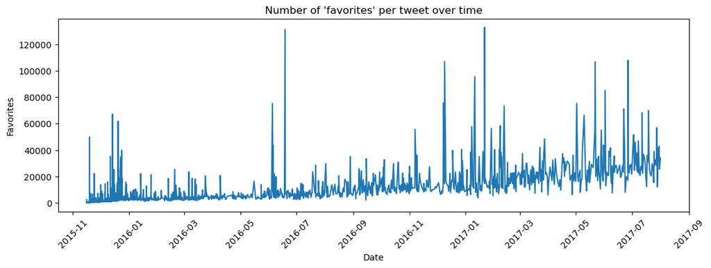

```python
#Plotting the number of retweets over time to see how the account's popularity has changed.
import matplotlib.pyplot as plt
%matplotlib inline
#tweets = tweets.set_index("timestamp") #Old code, didn't work
#plt.plot(tweets.favorite_count) #Old code, didn't work


tweets['timestamp'] = pd.to_datetime(tweets['timestamp'])
tweets = tweets.sort_values('timestamp')
plt.figure(figsize=(13,4))
plt.xlabel("Date")
plt.ylabel("Favorites")
plt.title("Number of 'favorites' per tweet over time")
plt.plot(tweets['timestamp'], tweets['favorite_count'])
plt.xticks(rotation=45);
plt.show();
```

This graph shows that the account's popularity grew over time. In 2015 it generally had fewer than 10,000 'favorites' per tweet, and by August 2017 it had closer to 30,000 'favorites' per tweet.